# The Evolution of chess. Literally.

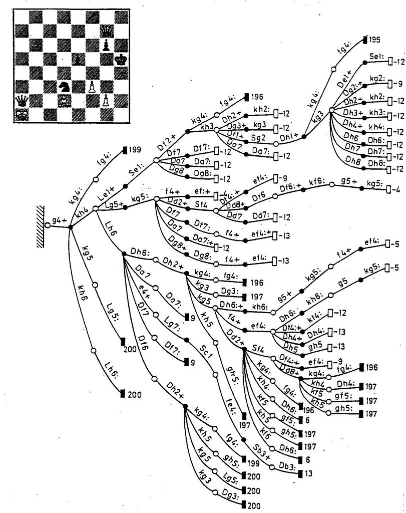

### Translating chess positions into protein sequences

The starting position of a chess game looks like this:

```r
library(rchess)

chss <- Chess$new()
fen <- "rnbqkbnr/pppppppp/8/8/8/8/PPPPPPPP/RNBQKBNR w KQkq - 0 1"
chss$load(fen)
```

```
[1] TRUE
```

```r
plot(chss)
```

[interactive chart not shown]

I told the computer how to set up this board using [Forsyth–Edwards Notation](https://en.wikipedia.org/wiki/Forsyth%E2%80%93Edwards_Notation) (FEN). FEN is a common way to describe board positions. The starting position above is written in FEN as:

**rnbqkbnr/pppppppp/8/8/8/8/PPPPPPPP/RNBQKBNR** w KQkq - 0 1

(The part that isn’t bold is metadata about the game and not needed to describe the board position.)

FEN is useful for recording and later setting up boards, but it’s going to be easier to do fancy evolution stuff with this data if we put it into a format that fancy evolution software understands: [**FASTA**](https://en.wikipedia.org/wiki/FASTA_format). FASTA is how DNA and protein sequence data are stored, and look like this:

>gi|186681228|ref|YP_001864424.1| phycoerythrobilin:ferredoxin oxidoreductase

MNSERSDVTLYQPFLDYAIAYMRSRLDLEPYPIPTGFESNSAVVGKGKNQEEVVTTSYAFQTAKLRQIRA

AHVQGGNSLQVLNFVIFPHLNYDLPFFGADLVTLPGGHLIALDMQPLFRDDSAYQAKYTEPILPIFHAHQ

QHLSWGGDFPEEAQPFFSPAFLWTRPQETAVVETQVFAAFKDYLKAYLDFVEQAEAVTDSQNLVAIKQAQ

LRYLRYRAEKDPARGMFKRFYGAEWTEEYIHGFLFDLERKLTVVK

Everything except for the first line is a protein sequence, with each amino acid in the protein being represented by a single letter code.

I want to encode a board position as a protein sequence by representing each square, and it’s state, as a single letter code. Similar to FEN, the first 8 amino acids will represent the 8th rank, and so on until the whole board is described. Each board sequence will be 64 amino acids long.

I translate the FEN above into FASTA like this:

**rnbqkbnr/pppppppp/8/8/8/8/PPPPPPPP/RNBQKBNR** —–> **ACDEFDCAGGGGGGGGIIIIIIIIIIIIIIIIIIIIIIIIIIIIIIIIPPPPPPPPRNVQKVNR**

#### algorithm for translation, with brief explanation

- **The black (r)ook, k(n)ight, (b)ishop, (q)ueen, (k)ing, (p)awn and white (B)ishop -> A, C, D, E, F, G, and V**:

  FASTA isn’t case sensitive, so I can’t represent black pieces as lower-case and white as upper-case like FEN does. Any unused amino acid code code be used, but I happened to choose the first 6 letters available to represent each black piece, and ‘V’ for the white bishop, as ‘B’ isn’t a valid code in FASTA.
- **‘8’ -> ‘IIIIIIII’**:

  Empty squares are now written as ‘I’, and every empty square is explicitly written. I did this because I want to be able to line up multiple game ‘sequences’ and know that every character *n* in each sequence represents the same square on the board so that I can then tell how many squares, after each move, look the same. If this reason doesn’t make sense, that’s fine. In short I did it to make comparisons between games more meaningful.
- **‘/’ -> ’’**:

  I got rid of the forward slashes. Now that I’m explicitly accounting for every square on the board, I don’t need them as dividers for the rows. Every 9th character is always the start of the next row.

After converting each board position within a game to FASTA format, I can stitch them all together, one after the other, and end up with an entire game encoded as a large protein.

**How large of a protein is a chess game?** Every board position is described by its 64 squares, with each square represented by a letter that also encodes a single amino acid in a protein sequence. An average game length is about 40 moves for white and 40 moves for black, with each move creating a board position different from the last. 64 squares x 80 moves = **5,120 amino acids**.

For reference, the average protein contains fewer than 500 amino acids, but [the largest we know of are around 30,000](https://en.wikipedia.org/wiki/Titin).

### Building a FASTA file of chess games

Eventually I want to analyze whole games by converting FEN -> FASTA, but unfortunately games are usually stored in a third format, [Portable Game Notation](https://en.wikipedia.org/wiki/Portable_Game_Notation) (PGN).

So my workflow is going to be to download games as PGN, convert to FEN, and then finally convert to FASTA for my analysis.

#### Load PGN files into R using ‘bigchess’

PGN files are essentially text files, and when processing a file with thousands of games, it’s nice to parse the text file into a dataframe that is easier to work with. The R package [bigchess](https://www.rdocumentation.org/packages/bigchess/versions/1.9.1) is a useful tool for this, but the *read.pgn* function returns a dataframe with way more information than I need, so I just remove all but the first 9 columns. Also, I merge the dataframes generated from each individual PGN file together. the result is a dataframe containing information for 17,346 London games, played from 1883-January 2020:

```r
library(bigchess)
library(magrittr) # allows me to use '%>% to atuomatically pipe an output of one command as input for another

# load one PGN:
e6.PGN <- file.path("./", 'London2e6.pgn') %>% read.pgn()
```

```
input string 73745 is invalid in this locale2021-01-30 13:30:38, successfully imported 7214 games
2021-01-30 13:30:38, N moves computed
2021-01-30 13:30:39, extract moves done
2021-01-30 13:30:43, stat moves computed
```

```r
# remove all but first 9 columns
e6.PGN <- e6.PGN[,1:9]
# Each game is stored as a row in the dataframe. let's look at the first game as an example:
head(e6.PGN, 1)
```

|  | Event | Site | Date | Round | White | Black | Result | Movetext | NMoves |
| --- | --- | --- | --- | --- | --- | --- | --- | --- | --- |
| 1 | London+ | London | 1883.??.?? | ? | Mason, James | Blackburne, Joseph Henry | 1/2-1/2 | 1.d4 e6 2.Nf3 Nf6 3.Bf4 d5 4.e3 Bd6 5.Bg3 O-O 6.Bd3 Ne4 7.Bxe4 dxe4 8.Nfd2 f5 9.O-O Nc6 10.Bxd6 cxd6 11.Nc3 d5 12.f4 b6 13.a3 Ba6 14.Rf2 Rc8 15.Nf1 Na5 16.Qe1 Qh4 17.g3 Qe7 18.Nd1 Rc7 19.b4 Nc4 20.a4 … | 33 |

```r
# I do the exact same thing for the second PGN:
g6.PGN <- file.path("./", 'London2g6.pgn') %>% read.pgn()
```

```
2021-01-30 13:30:45, successfully imported 10132 games
2021-01-30 13:30:46, N moves computed
2021-01-30 13:30:48, extract moves done
2021-01-30 13:30:55, stat moves computed
```

```r
g6.PGN <- g6.PGN[,1:9]

# merge the dataframes:
London.PGN <- merge(g6.PGN,e6.PGN, all = T)

# Let's look at the final dataframe structure
str(London.PGN)
```

```
'data.frame':   17346 obs. of  9 variables:
 $ Event   : chr  "100th ch-GBR 2013" "100th ch-GBR 2013" "101st ch-GBR 2014" "101st ch-GBR 2014" ...
 $ Site    : chr  "Torquay ENG" "Torquay ENG" "Aberystwyth WLS" "Aberystwyth WLS" ...
 $ Date    : chr  "2013.08.02" "2013.08.06" "2014.07.27" "2014.07.30" ...
 $ Round   : chr  "5.13" "8.49" "8.28" "11.27" ...
 $ White   : chr  "Anderson,J" "Bonafont,P" "Hughes,Ro" "Hughes,Ro" ...
 $ Black   : chr  "Arkell,K" "Kalaiyalahan,Akshaya" "Fraser,John" "Clancy,Martin J" ...
 $ Result  : Ord.factor w/ 4 levels "1-0"<"1/2-1/2"<..: 3 3 1 3 2 3 1 1 1 2 ...
 $ Movetext: chr  "1.d4 Nf6 2.Nf3 e6 3.Bf4 c5 4.e3 cxd4 5.exd4 Be7 6.Bd3 b6 7.O-O O-O 8.h3 Bb7 9.Nbd2 d6 10.Re1 Nbd7 11.c3 Re8 12."| __truncated__ "1.d4 Nf6 2.Nf3 g6 3.Bf4 Bg7 4.e3 d6 5.Be2 O-O 6.O-O Nh5 7.Bg5 h6 8.Bh4 c5 9.c3 Nf6 10.Nbd2 b6 11.a4 a6 12.b4 cx"| __truncated__ "1.d4 Nf6 2.Nf3 g6 3.Bf4…
 $ NMoves  : num  65 59 100 39 24 32 40 71 71 97 ...
```

*London.PGN* is very close to what I want the final data structure to look like, but the column ‘Movetext’ contains too much data in one column and is in a format (a string of characters) that is too difficult to parse. This single cell contains every move made in a game, and I’m going to want to easily move through a game move-by-move to convert each position seen in the game to FEN so it’s worth improving on it.

Ideally, I would like two split this column into two, *White.moves* and *Black.moves,* each containing a list of all moves played by the respective player, in the order they played them. This way I can iterate through each list in a simple loop.

Let’s do that:

```r
library(stringr)

# These will be a list of lists of white and black moves. eventually these will be our new columns
white <- list()
black <- list()


# 'game' represents the movetext for a single game, so this loops over all games' movetexts
for (game in London.PGN$Movetext)
  {

    # Split each move using spaces as separators
    all.moves <- strsplit(game, " ")

    # Black's moves are easier to process because they don't have the move numbers
    # attached to them. I make a list of black moves from the even numbered items in all.moves
    b <- list(all.moves[[1]][c(F,T)])
    black <- c(black,b)

    # I do the same for white, grabbing the odd numbered items in all.moves,
    # but I also need to remove the move number and period after it using lapply and gsub.
    w <- list(all.moves[[1]][c(T,F)])
    w <- lapply(w, function(x) gsub("^.*\\.","",as.character(x)))
    white <- c(white,w)

  }

# now I just make new columns in the df and assign our newly created move lists to them.
London.PGN$White.moves <- white
London.PGN$Black.moves <- black

# We're done!

# This column:
London.PGN$Movetext[1]
```

```
[1] "1.d4 Nf6 2.Nf3 e6 3.Bf4 c5 4.e3 cxd4 5.exd4 Be7 6.Bd3 b6 7.O-O O-O 8.h3 Bb7 9.Nbd2 d6 10.Re1 Nbd7 11.c3 Re8 12.Qe2 Bf8 13.Bg5 Qc7 14.Ne4 Nxe4 15.Bxe4 Bxe4 16.Qxe4 h6 17.Be3 b5 18.a3 Nf6 19.Qh4 Nd5 20.g4 Qb7 21.Qg3 a5 22.g5 Nxe3 23.Rxe3 g6 24.Nd2 hxg5 25.Ne4 Be7 26.Nxd6 Bxd6 27.Qxd6 Rad8 28.Qg3 …
```

```r
# Became these two columns:
London.PGN$White.moves[1]
```

```
[[1]]
 [1] "d4"   "Nf3"  "Bf4"  "e3"   "exd4" "Bd3"  "O-O"  "h3"   "Nbd2" "Re1"  "c3"   "Qe2"  "Bg5"  "Ne4"  "Bxe4" "Qxe4" "Be3"  "a3"   "Qh4"  "g4"   "Qg3"  "g5"   "Rxe3" "Nd2"  "Ne4"  "Nxd6" "Qxd6" "Qg3"
[29] "Rae1" "axb4" "Re5"  "Qxe5" "bxc3" "d5"   "Qxd5" "Re5"  "Rxd5" "Rxg5" "Kg2"  "Ra5"  "Ra6"  "Ra2"  "Rb2"  "Ra2"  "Rb2"  "Ra2"  "Ra8"  "Rb8"  "Rf8+" "Rg8"  "Ra8"  "Ra5+" "Rb5"  "Ra5"  "Ra2"  "Ra7"
[57] "Rg7+" "Rf7+" "Kf1"  "Rf8"  "Ra8"  "Kg2"  "Kg3"  "Kh4"  "Re8+"
```

```r
London.PGN$Black.moves[1]
```

```
[[1]]
 [1] "Nf6"  "e6"   "c5"   "cxd4" "Be7"  "b6"   "O-O"  "Bb7"  "d6"   "Nbd7" "Re8"  "Bf8"  "Qc7"  "Nxe4" "Bxe4" "h6"   "b5"   "Nf6"  "Nd5"  "Qb7"  "a5"   "Nxe3" "g6"   "hxg5" "Be7"  "Bxd6" "Rad8" "Rd5"
[29] "b4"   "axb4" "Rxe5" "bxc3" "Rc8"  "Qxd5" "exd5" "Rxc3" "Rxh3" "Kg7"  "Rd3"  "f6"   "g5"   "Kg6"  "g4"   "Kg5"  "f5"   "f4"   "Rd6"  "Kf5"  "Rf6"  "Rf7"  "Rg7"  "Kf6"  "Rg8"  "Rd8"  "Kg5"  "Rd2"
[57] "Kf5"  "Ke5"  "Rb2"  "Ke4"  "Rb1+" "f3+"  "Rg1+" "g3"   "Kd5"
```

#### Converting PGN to FEN using ‘rchess’

The R package [‘rchess’](http://jkunst.com/rchess/) has some useful functions for playing chess programmatically. I used it to generate the chessboard shown earlier, and I can use it again to play through each game in my dataframe, one move at a time, creating FEN descriptions of the board after each move.

```r
library(rchess)

# We need a place to put our stuff
FEN <- c()

# For every game in df: 1) make a move for white and record the board position, 2) check if there's a reply from black, and if so, 3) make black's move and record the position. Repeat until all moves are played. TRYCATCH: rarely, there is an error in a game's notation which makes a move not legal/not a real move. So I wrap any move attempt in a TryCatch statement and throw out the offending game altogether as invalid.

for (game in 1:nrow(London.PGN))
{
  # create a place to store FEN positions for the game,
  # create new chessboard with starting position
  game.FEN <- list()
  chss <- Chess$new()
  chss$load("rnbqkbnr/pppppppp/8/8/8/8/PPPPPPPP/RNBQKBNR w KQkq - 0 1") #starting position
  game.FEN <- c(game.FEN,chss$fen())
  # assign some ugly things some pretty names
  w.moves <- London.PGN$White.moves[game]
  b.moves <- London.PGN$Black.moves[game]

  valid.game = T

  for (i in 1:length(w.moves[[1]]))
  {


    if (valid.game)
    {
      tryCatch(
        {
            # try to make a legal move for white
            chss$move(w.moves[[1]][i])
        },
        error = function(e){
            valid.game = FALSE
        }
      )
      # record the position after white's move
      game.FEN <- c(game.FEN,chss$fen())

      # check if there is a move for black
      if (i <= length(b.moves[[1]]))
      {

        tryCatch(
          {
              # try to make a legal move for black
              chss$move(b.moves[[1]][i])
          },
          error = function(e){
              valid.game = FALSE
          }
        )
      # record the position after black's move
      game.FEN <- c(game.FEN,chss$fen())
      }
    } else
    {
      game.FEN <- c("INVALID")
      break
    }
  }

  # add the game's FENs to a running list
  FEN <- c(FEN,list(game.FEN))
}

# Add it all to the df
London.PGN$FEN <- FEN
```

#### Translating FEN to FASTA

All of these are simple replacements and can be made at once with a single call to str_replace_all:

```r
# We need a place to put our stuff
FASTA.colmn <- c()

for (game in 1:nrow(London.PGN))
  {
    # assign a nicer name to the game's list of FENs
    FENs <- London.PGN$FEN[game]

    FASTAs <- str_replace_all(FENs[[1]], c("r" = "A",
                       "n" = "C",
                       "b" = "D",
                       "q" = "E",
                       "k" = "F",
                       "p" = "G",
                       "B" = "V",
                       "1" = "I",
                       "2" = "II",
                       "3" = "III",
                       "4" = "IIII",
                       "5" = "IIIII",
                       "6" = "IIIIII",
                       "7" = "IIIIIII",
                       "8" = "IIIIIIII",
                       "/" = ""))

    # now that all board positions for this game are 64 chacters long, I can trim
    # the metadata off the end based on this character length

    for (i in 1:length(FASTAs))
    {
      FASTAs[i] <- substr(FASTAs[i], 1, 64)
    }

    #now let's collapse the vector of individual positions into one string that
    #represents the whole game
    FASTA <- paste(FASTAs, sep = '', collapse = '')
    # and add the new FASTA sequence to the running list
    FASTA.colmn <- c(FASTA.colmn, FASTA)
}


# and lastly add the FASTA sequences as a new column to our df
London.PGN$FASTA <- FASTA.colmn
```

#### Writing a FASTA file using ‘seqinr’

The hardest part of making the FASTA file is over, but we still need to assemble the parts.

FASTA files can hold multiple sequences, just like PGN files can hold multiple chess games. In a multi-FASTA, each new sequence starts with a ‘>’ followed by a short single line description. the next line is the start of the sequence.

In the end, the file should look something like this:

>Esipenko, Carlsen, 1-0, Tata Steel Masters, Wijk aan Zee, 24 Jan 2021

ACDEFDCAGGGGGGGGIIIIIIIIIIIIIIIIIIIIIIIIIIIIIIIIPPPPPPPPRNVQKVNRACDEFDCAGGGGGGGGIIIIIIIIIIIIIIIIIIIIIIIIIIIIPIIIPPPPIPPPRNVQKVNR…

>Rosen, Kristiansen, 1-0, Xtracon Chess Open, Elsinore, 23 Jul 2017

ACDEFDCAGGGGGGGGIIIIIIIIIIIIIIIIIIIIIIIIIIIIIIIIPPPPPPPPRNVQKVNRACDEFDCAGGGGGGGGIIIIIIIIIIIIIIIIIIIIIIIIIIIPIIIIPPPIPPPPRNVQKVNR…

I could do this all manually, but the R package [seqinr](https://www.rdocumentation.org/packages/seqinr/versions/4.2-5) makes it even easier:

```r
library(seqinr)
#write.fasta(sequences, names, file.out, open = "w", nbchar = 60, as.string = FALSE)
# for the seqinr function 'write.fasta', it expects a vector of sequences, and a vector of names, so let's make those

names <- c()
sequences <- c()

# One more time, I will loop through all the games
for (game in 1:nrow(London.PGN)){

  # This is all the information about the games I care about:
  white <- London.PGN$White[game]
  black <- London.PGN$Black[game]
  result <- London.PGN$Result[game]
  site <- London.PGN$Site[game]
  date <- London.PGN$Date[game]
  game.ID<- paste(white,black,date, sep = " - ")
  # I can name the game whatever I want, but I want to be able to parse it easily later,
  # so I am going to choose " | " as a unique separater between each piece of information

  game.name <- paste(white, black, result, site, date, sep = " | ")

  # this line isn't necessary really, but it makes it more ecplicit what I'm doing
  game.sequence <- London.PGN$FASTA[game]

  # add name and sequence to their respective list
  names <- c(names, game.name)
  sequences <- c(sequences, game.sequence)
}

# Now that we have our lists, we can finally build the FASTA file.
write.fasta(as.list(sequences), names, "LondonGames.fasta", open = "w", as.string = FALSE)
```